## **Linear Regression on movies data**

Author: Bruno Hunkeler  
Date: 21.09.2016

Rotten Tomatoes and the Tomatometer™ rating is the most trusted measurement of quality entertainment. As the leading online aggregator of movie and TV show reviews from professional critics, Rotten Tomatoes offers the most comprehensive guide to what’s fresh. The world famous Tomatometer™ rating represents the percentage of positive professional reviews for films and TV shows and is used by millions every day, to help with their entertainment viewing decisions. Rotten Tomatoes designates the best reviewed movies and TV shows as Certified Fresh. That accolade is awarded with Tomatometer ratings of 75% and higher, and a required minimum number of reviews. Weekly Rotten Tomatoes podcasts can be found on RottenTomatoes.com, iTunes, Soundcloud and Stitcher, and Rotten Tomatoes’ entertainment experts make regular TV and radio appearances across the US.

In 2016, Flixster and Rotten Tomatoes became part of Fandango’s portfolio of digital properties, serving moviegoers and entertainment fans. The Tomatometer rating – based on the published opinions of hundreds of film and television critics – is a trusted measurement of movie and TV programming quality for millions of moviegoers. It represents the percentage of professional critic reviews that are positive for a given film or television show.

**What is the Tomatometer?**  
The Tomatometer rating - based on the published opinions of hundreds of film and television critics - is a trusted measurement of movie and TV programming quality for millions of moviegoers. The Tomatometer rating represents the percentage of professional critic reviews that are positive for a given film or television show. Back in the days of the open theaters, when a play was particularly atrocious, the audience expressed their dissatisfaction by not only booing and hissing at the stage, but throwing whatever was at hand – vegetables and fruits included.

- The full popcorn bucket means the movie received 3.5 stars or higher by Flixster and Rotten Tomatoes users.
- The tipped over popcorn bucket means the movie received less than 3.5 stars by Flixster and Rotten Tomatoes users.
- The plus sign will appear for movies that do not have audience ratings or reviews. The percentage you see associated with this icon is the percentage of users who added the movie to their Want-to-See list.

**What is the audience score?**  
The Audience rating, denoted by a popcorn bucket, is the percentage of all Flixster.com and RottenTomatoes.com users who have rated the movie or TV Show positively.

- A good review is denoted by a fresh red tomato. In order for a movie or TV show to receive an overall rating of Fresh, the reading on the Tomatometer for that movie must be at least 60%.
- A bad review is denoted by a rotten green tomato splat (59% or less).
- To receive a Certified Fresh rating a movie must have a steady Tomatometer rating of 75% or better. Movies opening in wide release need at least 80 reviews from Tomatometer Critics (including 5 Top Critics). Movies opening in limited release need at least 40 reviews from Tomatometer Critics (including 5 Top Critics). A TV show must have a Tomatometer Score of 75% or better with 20 or more reviews from Tomatometer Critics (including 5 Top Critics). If the Tomatometer score drops below 70%, then the movie or TV show loses its Certified Fresh status. In some cases, the Certified Fresh designation may be held at the discretion of the Rotten Tomatoes editorial team.

### **Data collection**

IMDb started in 1990 as a hobby project by an international group of movie and TV fans. IMDb is now the world’s most popular and authoritative source for movie, TV and celebrity content.

The information in IMDb comes from various sources. While they actively gather information from and verify items with studios and filmmakers, the bulk of our information is submitted by people in the industry and visitors like you. In addition to using as many sources as we can, the data goes through consistency checks to ensure it’s as accurate and reliable as possible. However, there’s absolutely no substitute for an international team of entertainment fans with an encyclopedic knowledge of trivia and a large assortment of reference works (and we include in this group many of our loyal contributors). The sources of information include, but are not limited to, on-screen credits, press kits, official bios, autobiographies, and interviews.

#### **Dataset and further Information**

Dataset and further information used to perform the given analysis were obtained from the following sources:

- Dataset: Movies Data
- Codebook: Movies Codebook
- Rotten Tomatoes: [Rotten Tomatoes](https://www.rottentomatoes.com/)
- IMDB: [IMDB](http://www.imdb.com/)

#### **Generalizability**

The present data were derived from an observational study. The data set is comprised of 651 randomly sampled movies produced and released from 1970 to 2014. According to IMDb, there have 9,962 movie release from 1972 to 2016 so that the 10% condition (9,962*10% = 996) is met. Since the sampling size is large enough and less than 10% of population, it can assume that the random sampling is conducted. Therefore we can conclude that the sample is indeed generalizable to the entire population.

#### **Causality**

The data cannot be used to establish a causal relation between the variables of interest as there was no random assignment to the explanatory and independent variables.

### **Setup**

#### **Load packages**

```r
library('ggplot2')      # library to create plots
library('dplyr')        # data manipulation
library('statsr')       # staistics functions
library('GGally')       # library to create plots
library('knitr')        # required to apply knitr options
library('grid')         # arrange plots
library('gridExtra')    # arrange plots
source('Utilities.R')   # support functions used in the analysis - See Appendix

# apply general knitr options
knitr::opts_chunk$set(comment=NA, fig.align='center')
```

#### **Load data**

Initial load of the dataset.

```r
load("Data/movies.Rdata")
data <- movies
```

### **Part 1: Data**

In order to examine the research question, the movies data from IMDB was used.

```r
# evaluate the size of the dataset
dim(data)
```

```
[1] 651  32
```

The output for the summary- and str() - function has been hidden since the output would be quiet exhaustive (verbose) by having 32 variables.

```r
# verify types and summary of each variable
str(data)
summary(data)
```

```r
table(data$genre)
```

```
       Action & Adventure                 Animation
                       65                         9
Art House & International                    Comedy
                       14                        87
              Documentary                     Drama
                       52                       305
                   Horror Musical & Performing Arts
                       23                        12
       Mystery & Suspense                     Other
                       59                        16
Science Fiction & Fantasy
                        9
```

The table above gives an idea of the number of occurences of different genres. Genre is assumed to be one of the central for predicting the audience_score. One can see that dramas have the highest representation in the given dataset. Therefore we can assume that certain types of movies will have a better prediction rate then others.

I went through the dataset to separate the wheat from the chaff. I verified the number of ‘NA’ in each variable. Check if it is required to apply an algorithm to fill in the missing data or if I just can delete the incomplete rows.

```r
Col <- colnames(data)

# Create a new dataset to explicitely show dataset containing NA's
data.full.na <- data[, Col]

# remove NA's
data.full <- data.full.na[complete.cases(data.full.na), ]
100 - round(dim(data.full)[1] * 100 / dim(data)[1], 2)
```

```
[1] 4.92
```

```r
Col <- c('title','title_type','genre','runtime','mpaa_rating','studio','thtr_rel_year','dvd_rel_year','imdb_rating','imdb_num_votes','critics_rating','critics_score','audience_rating','audience_score','best_pic_nom','best_pic_win','best_actor_win','best_actress_win','best_dir_win','top200_box','director')

# Create a new dataset to explicitely show dataset containing NA's
data.full.na <- data[, Col]

# remove NA's
data.full <- data.full.na[complete.cases(data.full.na), ]
100 - round(dim(data.full)[1] * 100 / dim(data)[1], 2)
```

```
[1] 2.92
```

Removing all NA’s from the original dataset would reduce the dataset by around 5%. We removed features, which we think will not contribute to the final model. These features are actor1, actor2 ,actor3 ,actor4 , actor5, imdb_url, rt_url. Having removed those columns from the dataset left us with a dataset reduced by around 3%. I decided to just remove the incomplete rows since the remaining data set still provides enough information. The number of removed rows will even be reduced more when we narrow down to the final model.

### **Part 2: Research question**

The following Research question is meant to be answered in this document.

- **Is it possible to predict the audience score, based on combination of features (e.g. genre, reviews, runtime, release date etc.)?**
- **Lead certain types of movies to a better audience score?**

**This is interesting to me for the following reason:**  
Producing movies is associated with lots of costs. Companies producing movies should focus their offerings on movies that the audience is likely to enjoy. It is essential to prevent investments in movies, which are a complete failure (missing the revenue goals).

### **Part 3: Exploratory data analysis**

#### **Summary and density distribution of the audience score**

The response variable of interest is the audience score. So we perform a few initial verifications.

```r
summary(data.full$audience_score)
```

```
   Min. 1st Qu.  Median    Mean 3rd Qu.    Max.
  11.00   46.00   65.00   62.57   80.00   97.00
```

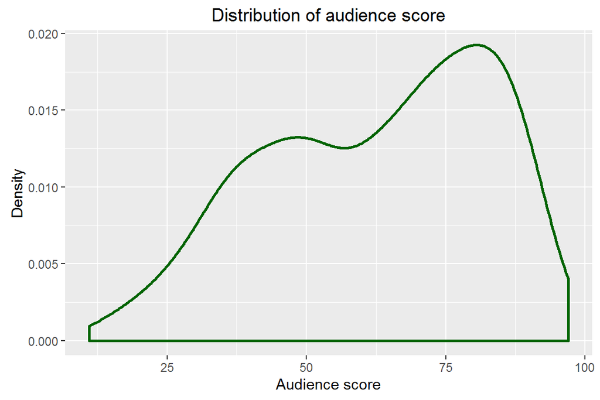

```r
g <- ggplot(data.full, aes(audience_score))
g + geom_density(size=1, colour="darkgreen") + labs(title = "Distribution of audience score") + labs(x = "Audience score", y = "Density")
```

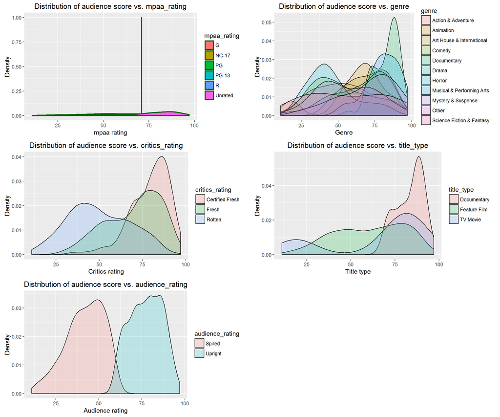

```r
p1 <- ggplot(data.full, aes(audience_score, fill = mpaa_rating))
p1 <- p1 + geom_density(size=1, colour="darkgreen") + labs(title = "Distribution of audience score vs. mpaa_rating") + labs(x = "mpaa rating", y = "Density")

p2 <- ggplot(data.full, aes(audience_score, fill = genre))
p2 <- p2 + geom_density (alpha = 0.2) + labs(title = "Distribution of audience score vs. genre") + labs(x = "Genre", y = "Density")

p3 <- ggplot(data.full, aes(audience_score, fill = critics_rating))
p3 <- p3 + geom_density (alpha = 0.2) + labs(title = "Distribution of audience score vs. critics_rating") + labs(x = "Critics rating", y = "Density")

p4 <- ggplot(data.full, aes(audience_score, fill = title_type))
p4 <- p4 + geom_density (alpha = 0.2) + labs(title = "Distribution of audience score vs. title_type") + labs(x = "Title type", y = "Density")

p5 <- ggplot(data.full, aes(audience_score, fill = audience_rating))
p5  <- p5 + geom_density (alpha = 0.2) + labs(title = "Distribution of audience score vs. audience_rating") + labs(x = "Audience rating", y = "Density")

grid.arrange(p1, p2, p3, p4, p5,  ncol = 2)
```

Although it might be possible to combine the actor’s names of a particular movie into a single numerical or categorical variable it would not aid the interpretability of the regression model. Moreover, given the small sample size, it is a distinct possibility that most actors’ names may not be meaningful predictors. The same applies to the features “imdb_url” and “rt_url”. Both won’t support a meaningful prediction. Above a selection of Density plots have been visualized. The plots show different features compared to the audience score. One can see that certain features will certainly contribute better (i.e genre, critics_rating etc.) to the model then others.

### **Part 4: Modeling**

#### **Model selection**

The best model is not always the most complicated. Sometimes including variables that are not evidently important can actually reduce the accuracy of predictions. In practice, the model that includes all available explanatory variables is often referred to as the full model. The full model may not be the best model, and if it isn’t, we want to identify a smaller model that is preferable. **Adjusted R<sup>2</sup>** describes the strength of a model, and it is a useful tool for evaluating which predictors are adding value to the model, where adding value means they are (likely) improving the accuracy in predicting future outcomes.

**Backwards elimination** was applied to select an appropriate model. Hereby I start with a full model (containing all predictors), drop one predictor at a time until the parsimonious model is reached. I focused on the adjusted R<sup>2</sup> value, since this leads to more reliable predictions. The analysis showed, that the following model give me the highest adjusted R<sup>2</sup> value.

**Model:**  
**audience_score ~ genre + runtime + dvd_rel_year + imdb_rating + imdb_num_votes + critics_score + audience_rating + best_pic_nom**

Backward Feature Elimination is a tedious task. Recursive Feature Elimination (RFE) is a helpful method in such a case. Out of an interest I used two independent approaches to retrieve a Parsimonious model. The types I used are listed below. A detailed implementation can be found in the appendix.

- **LEAP - Recursive feature elimination (part of the Leaps Package)**
- **stepAIC - Recursive feature elimination (part of the MASS Package)**

#### **Model evaluation**

The following model is used for model evaluation.  
**audience_score ~ genre + runtime + dvd_rel_year + imdb_rating + imdb_num_votes + critics_score + audience_rating + best_pic_nom**

```r
Col <- c('genre','runtime','dvd_rel_year', 'imdb_rating', 'imdb_num_votes', 'critics_score', 'audience_rating', 'audience_score', 'best_pic_nom')
data.full.na <- data[, Col]

# remove NA's
data.full <- data.full.na[complete.cases(data.full.na), ]

# Create Formula
formula <- getFormula(data.full, 'audience_score')
lm.movies <- lm(formula, data.full)

summary(lm.movies)
```

```
Call:
lm(formula = formula, data = data.full)

Residuals:
     Min       1Q   Median       3Q      Max
-21.8021  -4.5495   0.4992   4.2506  23.8522

Coefficients:
                                 Estimate Std. Error t value Pr(>|t|)
(Intercept)                     2.866e+02  1.235e+02   2.320   0.0207 *
genreAnimation                  3.377e+00  2.472e+00   1.366   0.1724
genreArt House & International -2.156e+00  2.139e+00  -1.008   0.3139
genreComedy                     1.257e+00  1.142e+00   1.101   0.2714
genreDocumentary                1.055e+00  1.505e+00   0.701   0.4834
genreDrama                     -6.719e-01  9.940e-01  -0.676   0.4993
genreHorror                    -1.933e+00  1.688e+00  -1.145   0.2526
genreMusical & Performing Arts  3.339e+00  2.232e+00   1.496   0.1352
genreMystery & Suspense        -3.120e+00  1.259e+00  -2.479   0.0134 *
genreOther                     -1.484e-01  1.939e+00  -0.077   0.9390
genreScience Fiction & Fantasy -6.089e-02  2.577e+00  -0.024   0.9812
runtime                        -3.522e-02  1.610e-02  -2.187   0.0291 *
dvd_rel_year                   -1.465e-01  6.148e-02  -2.383   0.0175 *
imdb_rating                     9.299e+00  4.821e-01  19.289   <2e-16 ***
imdb_num_votes                  3.617e-06  2.943e-06   1.229   0.2196
critics_score                   2.327e-02  1.513e-02   1.538   0.1246
audience_ratingUpright          1.990e+01  7.881e-01  25.253   <2e-16 ***
best_pic_nomyes                 2.901e+00  1.617e+00   1.793   0.0734 .
---
Signif. codes:  0 '***' 0.001 '**' 0.01 '*' 0.05 '.' 0.1 ' ' 1

Residual standard error: 6.845 on 624 degrees of freedom
Multiple R-squared:  0.8876,    Adjusted R-squared:  0.8845
F-statistic: 289.9 on 17 and 624 DF,  p-value: < 2.2e-16
```

The summary of our parsimonious model indicates that the adjusted R<sup>2</sup> value is 0.8845 and the p-value: < 2.2e-16.

Summary estimates should only be trusted if the conditions for the regression are reasonable. Having mentioned that, it will be relevant to validate the following aspects:

1. There is a linear relationship between any numerical predictor variables and the response variable.
2. The residuals are nearly normally distributed
3. The residuals display constant variability
4. The residuals are independent

We first will examine whether the numerical variables included in the model, are linearly related to the response variable (audience score) by examining the distribution of the residuals.

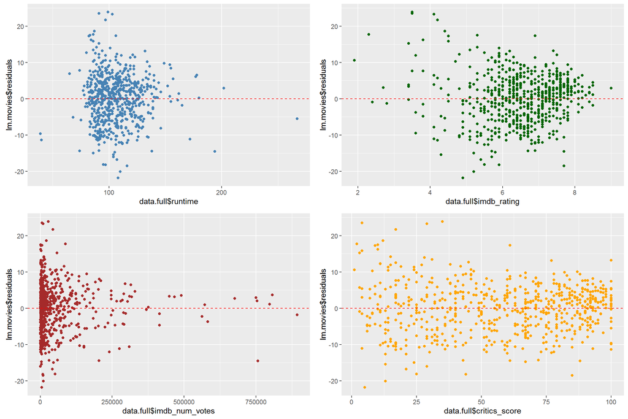

```r
p1 <- ggplot(data = NULL, aes(x = data.full$runtime, y = lm.movies$residuals)) +
      geom_point(col = 'steelblue') + geom_hline(yintercept = 0, linetype = 'dashed', color = 'red')

p2 <- ggplot(data = NULL, aes(x = data.full$imdb_rating, y = lm.movies$residuals)) +
      geom_point(col = 'darkgreen') + geom_hline(yintercept = 0, linetype = 'dashed', color = 'red')

p3 <- ggplot(data = NULL, aes(x = data.full$imdb_num_votes, y = lm.movies$residuals)) +
      geom_point(col = 'brown') + geom_hline(yintercept = 0, linetype = 'dashed', color = 'red')

p4 <- ggplot(data = NULL, aes(x = data.full$critics_score, y = lm.movies$residuals)) +
      geom_point(col = 'orange') + geom_hline(yintercept = 0, linetype = 'dashed', color = 'red')

grid.arrange(p1, p2, p3, p4)
```

The residuals are scattered randomly around 0 for all features.

Next, we check whether the residuals display a nearly normal distribution centred around 0.

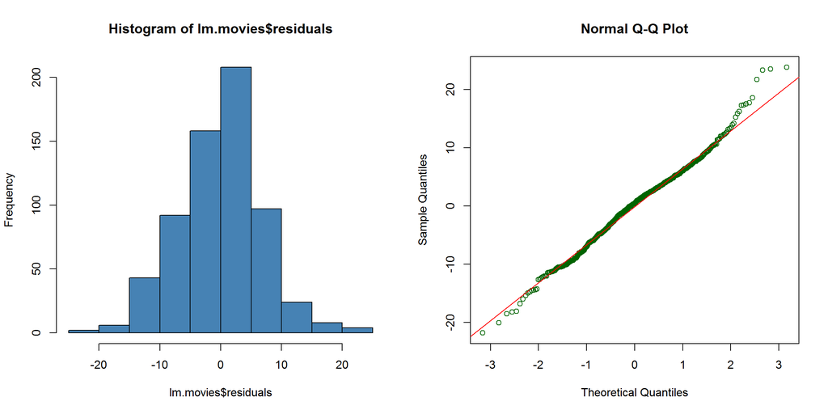

```r
par(mfrow = c(1,2))
hist(lm.movies$residuals, col = 'steelblue')
qqnorm(lm.movies$residuals, col = 'darkgreen')
qqline(lm.movies$residuals, col = 'red')
```

The results of the histogram of the residuals shows a normal distribution around 0 while the Q-Q plot indicates some skewness in the tails but there are no major deviations. So we can conclude that the conditions for this model are reasonable.

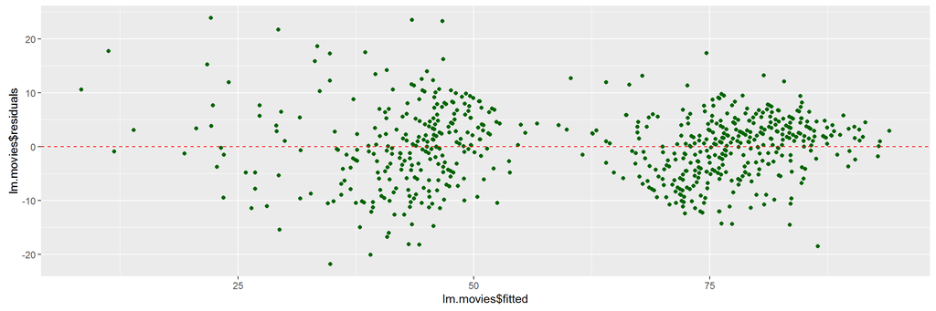

```r
par(mfrow = c(1,2))
ggplot(data = NULL, aes(x = lm.movies$fitted, y = lm.movies$residuals)) + geom_point(col = 'darkgreen') +
      geom_hline(yintercept = 0, linetype = 'dashed', color = 'red')
```

We can also perform a hierarchical analysis of variance table by using the **anova** function: An ANOVA table shows the possible associations between the independent and dependent variables. That Information gets lost in the summary output of a t-test. The results of the ANOVA test are shown below.

```r
anova(lm.movies)
```

```
Analysis of Variance Table

Response: audience_score
                 Df Sum Sq Mean Sq   F value    Pr(>F)
genre            10  49495    4950  105.6396 < 2.2e-16 ***
runtime           1   6023    6023  128.5498 < 2.2e-16 ***
dvd_rel_year      1   3428    3428   73.1557 < 2.2e-16 ***
imdb_rating       1 140510  140510 2998.9601 < 2.2e-16 ***
imdb_num_votes    1    404     404    8.6295   0.00343 **
critics_score     1    963     963   20.5562 6.944e-06 ***
audience_rating   1  29925   29925  638.6985 < 2.2e-16 ***
best_pic_nom      1    151     151    3.2160   0.07341 .
Residuals       624  29236      47
---
Signif. codes:  0 '***' 0.001 '**' 0.01 '*' 0.05 '.' 0.1 ' ' 1
```

With regards to inference for the model, the p-value of the model’s F-statistic indicates that the model as a whole is significant. It should be noted that not all explanatory variables have a significant p-value as the model was developed using **highest adjusted R<sup>2</sup>** as a determinant.

#### **Correlation of features (Collinearity)**

Correlation Coefficients are used to describe relationships among quantitative variables/features.  
The sign ± indicates the direction of the relationship (positive or inverse) and the magnitude indicates the strength of the relationship (ranging from 0 for no relationship to 1 for a perfectly predictable relationship). Finding the final model is a compromise between predictive accuracy (a model that fits the data as well as possible) and parsimony. Predictors are independent variables, so they should be independent of each other. Predictors are collinear when they are correlated with each other. In favour of this approach we will verify the correlation between the different numerical features. Non numerical features can’t be used to assess correlation.

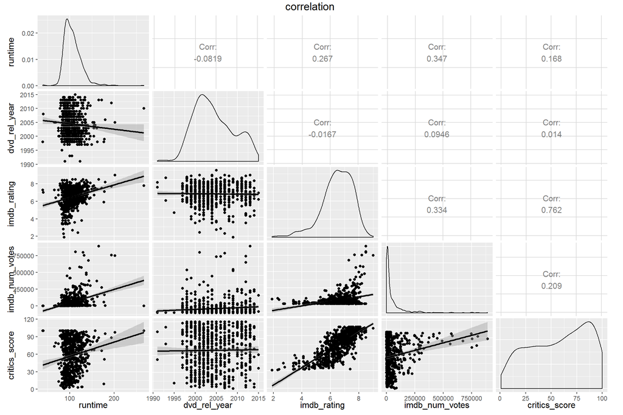

```r
Col <- c('genre','runtime','dvd_rel_year','imdb_num_votes','critics_score','audience_rating','audience_score','best_pic_nom')
data.cor.na <- data[, Col]

# remove NA's
data.cor<- data.cor.na[complete.cases(data.cor.na), ]

# Create Formula
formula <- getFormula(data.cor, 'audience_score')
lm.cor <- lm(formula, data = data.cor)

Col <- c('runtime','dvd_rel_year','imdb_rating','imdb_num_votes','critics_score')
data.cor <- data.full[, Col]

ggpairs(data.cor,
        columns=1:5,
        upper = list(continuous = wrap("cor", size = 4)),
        lower = list(continuous = "smooth"),
        title="correlation ",
        colour = "critics_score")
```

The given image shows a strong relation (correlation) in one area. There is a positive Correlation of 0.76 between the predictors ‘critics_score’ and ‘imdb_rating’. There seems to be a collinearity between the given predictors. This finding requires to run a second model with a reduced feature set. In the new model we remove ‘critics_score’ and run the model again. Having two models at hand requires the step of comparing them. That step is discussed in the next section.

```r
# reduced feature list
Col <- c('genre','runtime','dvd_rel_year','imdb_rating','imdb_num_votes','audience_rating','audience_score','best_pic_nom')
data.cor.na <- data[, Col]

# remove NA's.
data.cor <- data.cor.na[complete.cases(data.cor.na), ]

# Create Formula
formula <- getFormula(data.cor, 'audience_score')
lm.cor <- lm(formula, data.cor)

summary(lm.cor)
```

```
Call:
lm(formula = formula, data = data.cor)

Residuals:
     Min       1Q   Median       3Q      Max
-22.3073  -4.4462   0.5947   4.2330  24.6016

Coefficients:
                                 Estimate Std. Error t value Pr(>|t|)
(Intercept)                     2.773e+02  1.235e+02   2.244   0.0252 *
genreAnimation                  3.537e+00  2.472e+00   1.431   0.1530
genreArt House & International -2.290e+00  2.139e+00  -1.070   0.2849
genreComedy                     1.321e+00  1.143e+00   1.156   0.2483
genreDocumentary                1.288e+00  1.499e+00   0.859   0.3905
genreDrama                     -5.257e-01  9.905e-01  -0.531   0.5958
genreHorror                    -1.792e+00  1.687e+00  -1.062   0.2887
genreMusical & Performing Arts  3.524e+00  2.232e+00   1.579   0.1148
genreMystery & Suspense        -3.025e+00  1.258e+00  -2.404   0.0165 *
genreOther                      7.743e-02  1.935e+00   0.040   0.9681
genreScience Fiction & Fantasy  2.164e-01  2.573e+00   0.084   0.9330
runtime                        -3.610e-02  1.611e-02  -2.241   0.0254 *
dvd_rel_year                   -1.426e-01  6.149e-02  -2.318   0.0207 *
imdb_rating                     9.712e+00  4.008e-01  24.231   <2e-16 ***
imdb_num_votes                  3.349e-06  2.941e-06   1.139   0.2553
audience_ratingUpright          2.004e+01  7.840e-01  25.555   <2e-16 ***
best_pic_nomyes                 3.076e+00  1.615e+00   1.905   0.0573 .
---
Signif. codes:  0 '***' 0.001 '**' 0.01 '*' 0.05 '.' 0.1 ' ' 1

Residual standard error: 6.852 on 625 degrees of freedom
Multiple R-squared:  0.8872,    Adjusted R-squared:  0.8843
F-statistic: 307.2 on 16 and 625 DF,  p-value: < 2.2e-16
```

The model (lm.cor) with the removed feature (critics_score) indicates that the **adjusted R<sup>2</sup>** value is **0.8843** and the **p-value: < 2.2e-16**. The features are significant to the model, but the adjusted R<sup>2</sup> value is slightly smaller then the original model. This can also be visualized as in the plots below.

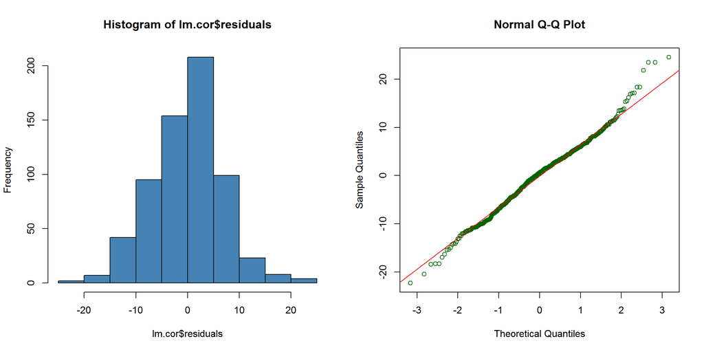

```r
par(mfrow = c(1,2))
hist(lm.cor$residuals, col = 'steelblue')
qqnorm(lm.cor$residuals, col = 'darkgreen')
qqline(lm.cor$residuals, col = 'red')
```

Since there is no substantial difference between the two outcomes, one could conclude to get rid of the critics_score in favour of a smaller model. But we will stick with the model initially proposed.

Here as well we can perform a hierarchical analysis of variance table by using the **anova** function.

```r
anova(lm.cor)
```

```
Analysis of Variance Table

Response: audience_score
                 Df Sum Sq Mean Sq   F value    Pr(>F)
genre            10  49495    4950  105.4094 < 2.2e-16 ***
runtime           1   6023    6023  128.2697 < 2.2e-16 ***
dvd_rel_year      1   3428    3428   72.9963 < 2.2e-16 ***
imdb_rating       1 140510  140510 2992.4250 < 2.2e-16 ***
imdb_num_votes    1    404     404    8.6107  0.003465 **
audience_rating   1  30757   30757  655.0397 < 2.2e-16 ***
best_pic_nom      1    170     170    3.6275  0.057289 .
Residuals       625  29347      47
---
Signif. codes:  0 '***' 0.001 '**' 0.01 '*' 0.05 '.' 0.1 ' ' 1
```

It reflects about the same result as in the previous anova analysis. The p-value of the model’s F-statistic indicates that the model as a whole is significant. Also here it should be noted that not all explanatory variables have a significant p-value as the model was developed using highest adjusted R2 as a determinant.

#### **Comparing models**

The selection of a final regression model always involves a compromise between predictive accuracy (a model that fits the data as well as possible) and parsimony (a simple and replicable model). All things being equal, if you have two models with approximately equal predictive accuracy, We would favour the simpler one. Will use anova to compare the model fit. Anova() compares the fit of two nested models. A nested model is one whose terms are completely included in the other model.

```r
# in favour of the output
model1 <- lm.movies
model2 <- lm.cor

# Compare Model fit
anova(model1, model2)
```

```
Analysis of Variance Table

Model 1: audience_score ~ genre + runtime + dvd_rel_year + imdb_rating +
    imdb_num_votes + critics_score + audience_rating + best_pic_nom
Model 2: audience_score ~ genre + runtime + dvd_rel_year + imdb_rating +
    imdb_num_votes + audience_rating + best_pic_nom
  Res.Df   RSS Df Sum of Sq      F Pr(>F)
1    624 29236
2    625 29347 -1    -110.8 2.3649 0.1246
```

Having selected the model based on adjusted R<sup>2</sup> or p-values does not per se mean that the model automatically generalizes better. I’d like to take both models to see how each model generalize by predicting values.

We will use both models to predict the **audience_score**, as mentioned above. We will then see, which model generalizes better. For that purpose I randomly selected 10 rows from the data set and predicted the values based on the models.

```r
data.prediction <- data.full[, -8]

prediction_1.1 <- predict(lm.movies, data.prediction[7,])
prediction_1.2 <- predict(lm.movies, data.prediction[17,])
prediction_1.3 <- predict(lm.movies, data.prediction[37,])
prediction_1.4 <- predict(lm.movies, data.prediction[57,])
prediction_1.5 <- predict(lm.movies, data.prediction[100,])
prediction_1.6 <- predict(lm.movies, data.prediction[131,])
prediction_1.7 <- predict(lm.movies, data.prediction[151,])
prediction_1.8 <- predict(lm.movies, data.prediction[170,])
prediction_1.9 <- predict(lm.movies, data.prediction[243,])
prediction_1.10 <- predict(lm.movies, data.prediction[316,])

data.prediction <- data.prediction[, -6]

prediction_2.1 <- predict(lm.cor, data.prediction[7,])
prediction_2.2 <- predict(lm.cor, data.prediction[17,])
prediction_2.3 <- predict(lm.cor, data.prediction[37,])
prediction_2.4 <- predict(lm.cor, data.prediction[57,])
prediction_2.5 <- predict(lm.cor, data.prediction[100,])
prediction_2.6 <- predict(lm.cor, data.prediction[131,])
prediction_2.7 <- predict(lm.cor, data.prediction[151,])
prediction_2.8 <- predict(lm.cor, data.prediction[170,])
prediction_2.9 <- predict(lm.cor, data.prediction[243,])
prediction_2.10 <- predict(lm.cor, data.prediction[316,])
```

The following table contains the predicted values and deviation in % of the prediction.

| Model (lm.movies) | Audience_score | Prediction | Deviation |
| --- | --- | --- | --- |
| model 1 | 76 | 75.66 | 0.45 % |
| model 1 | 80 | 76.77 | 4.04 % |
| model 1 | 70 | 73.91 | -5.58 % |
| model 1 | 59 | 49.63 | 15.88 % |
| model 1 | 80 | 76.80 | 4.00 % |
| model 1 | 87 | 80.24 | 7.77 % |
| model 1 | 85 | 77.37 | 8.97 % |
| model 1 | 32 | 36.11 | -12.84 % |
| model 1 | 66 | 73.32 | -11.09 % |
| model 1 | 84 | 75.31 | 10.34 % |

| Model (lm.cor) | Audience_score | Prediction | Deviation |
| --- | --- | --- | --- |
| model 2 | 76 | 76.02 | -0.04 % |
| model 2 | 80 | 77.16 | 3.55 % |
| model 2 | 70 | 73.76 | -5.37 % |
| model 2 | 59 | 49.85 | 15.50 % |
| model 2 | 80 | 76.40 | 4.50 % |
| model 2 | 87 | 80.17 | 7.85 % |
| model 2 | 85 | 76.82 | 9.62 % |
| model 2 | 32 | 36.40 | -13.75 % |
| model 2 | 66 | 73.20 | -10.90 % |
| model 2 | 84 | 76.54 | 8.88 % |

Both the models generalize in about the same way. Therefore we will stick with the model we initially proposed (lm.movies.).

### **Part 5: Prediction**

Finally, I’ll provide the predicted value, based on a 95% confidence interval. I used the movie Sully for that purpose.

```r
data.prediction <- data.frame( genre = 'Drama',
                               runtime = 96,
                               dvd_rel_year = 2016,
                               imdb_rating = 8.0,
                               imdb_num_votes = 21057,
                               critics_score = 82,
                               audience_rating = 'Upright',
                               best_pic_nom = 'yes')
predict(lm.movies, data.prediction, interval = "prediction", level = 0.95)
```

```
       fit      lwr      upr
1 86.35879 72.41683 100.3008
```

```r
# Error in percent
Error_in_percent = round(100 - (round(86.35, 2) * 100 / 89), 2)
Error_in_percent
```

```
[1] 2.98
```

The predicted value is 86.36, which fairly close to the actual audience score of 89 and, based on the confidence interval, we can be 95% confident that the actual audience score for this particular movie has a lower bound of approximately 72.42 and a higher bound of approximately 100.30. The calculated Error between eff. audience score (89) and predicted audience score (86.36) is about **2.97 %**

### **Part 6: Conclusion**

The predictive model presented here is used to predict audience scores for a movie. To get to a Parsimonious model with ‘backward elimination’ manually is a rather tedious task. Therefore Recursive Feature Elimination is pretty helpful method in such cases. We used the adjusted R<sup>2</sup> parameter to narrow down the features to a Parsimonious model, which leads to more reliable predictions. The proposed linear model shows a ‘fairly good’ prediction rate, but it should be noted that the model is based on a very small sample.

It might be beneficial to gather more data for a better prediction. Especially the distribution of movies from different genres is certainly unsufficient. The only sufficiently represented genre type in the present dataset, is dramas (about 50%). The predicion of the ‘audience score’ for movies in other genres will indicate larger differences.

Lower bound audience_scores show a much higher difference. Therefore we might think about a second or higher order polynomial model. But we still need be carefull to find a decent balance between over-, and underfitting the model.

A useful additional analysis would be, to evaluate if we end up with better prediction results, if we focus on p-values (significant predictores) to evaluate predictors.

One last word. Having selected the model based on adjusted R<sup>2</sup> or p-values does not per se mean that the model automatically generalizes better. So you are still free to add or remove certain predictors for the greater good. It’s called the expert opinion.

### **Appendix**

#### getFormula Function

The following Function has been used throughout the project. It is just a convenience function to improve the readability.

```r
# ==========================================================================================================
# getFormula  - will retrieve the formula based on a data set
#
# Parameter:
#   data  - dataset
#   label - label
# ==========================================================================================================

getFormula <- function(data = data, label = label) {

  # label Variable
  labelVar <- label

  # separate measure Variable y column from rest
  groupVariables <- setdiff(colnames(data), list(label))

  # create formula for model
  formula <- as.formula(paste(labelVar, paste(groupVariables, collapse = ' + '), sep = ' ~ '))

}
```

#### Recursive Feature Elimination (RFE)

I used the following methods to perform RFE.

- **LEAP - Recursive feature elimination (part of the Leaps Package)**
- **stepAIC - Recursive feature elimination (part of the MASS Package)**

```r
LEAP <- FALSE

if (LEAP == TRUE) {
  library(leaps)  # Recursive Feature Elimination functions

  Col <- c('title_type','genre','runtime','mpaa_rating','thtr_rel_year','dvd_rel_year','imdb_rating','imdb_num_votes','critics_rating','critics_score','audience_rating','audience_score','best_pic_nom')
  data.full.na <- data[, Col]
  data.full <- data.full.na[complete.cases(data.full.na), ]

  # Create Formula
  formula <- getFormula(data.full, 'audience_score')
  leaps <- regsubsets(formula, data=data.full, nbest = 1, nvmax = NULL, method = "backward")
  plot(leaps, scale = "adjr2", main = "Adjusted R^2")

}

AIC <- FALSE

if(AIC == TRUE){
  library('MASS')  # Recursive Feature Elimination functions

  Col <- c('title_type','genre','runtime','mpaa_rating','thtr_rel_year','dvd_rel_year','imdb_rating','imdb_num_votes','critics_rating','critics_score','audience_rating','audience_score','best_pic_nom')
  data.AIC.na <- data[, Col]

  # remove NA's
  data.AIC <- data.AIC.na[complete.cases(data.AIC.na), ]

  # Create Formula
  formula <- getFormula(data.AIC, 'audience_score')
  lm.AIC <- lm(formula, data = data.AIC)

  parameter.final <- stepAIC(lm.AIC, direction='backward')

}
```

Both the Methods return reasonable results, even though they are different. Therefore don’t just trust the provided solution. Reverify the respective solution in regards to adjusted R<sup>2</sup> or p-value. I reduced the features above already by the parameters, which obviously do not contribute to the prediction. The reason is to reduce the evaluation time.